# Optimal Treatment Analysis

## Outcome Variable

**Outcome Variable:** ever_stunted

## Predictor Variables

**Intervention Variable:** nrooms

**Adjustment Set:**

- arm
- sex
- W_mage
- meducyrs
- feducyrs
- hhwealth_quart
- hfoodsec
- W_mhtcm
- W_nchldlt5
- W_parity
- impfloor
- impsan
- safeh20
- delta_W_mage
- delta_meducyrs
- delta_feducyrs
- delta_hhwealth_quart
- delta_hfoodsec
- delta_W_mhtcm
- delta_W_nchldlt5
- delta_W_parity
- delta_impfloor
- delta_impsan
- delta_safeh20

## Stratifying Variables

The analysis was stratified on these variable(s):

- agecat
- studyid
- country

## Data Summary

| agecat | studyid | country | nrooms | ever_stunted | n_cell | n |
| --- | --- | --- | --- | --- | --- | --- |
| 0-24 months | ki0047075b-MAL-ED | BANGLADESH | 4+ | 0 | 8 | 242 |
| 0-24 months | ki0047075b-MAL-ED | BANGLADESH | 4+ | 1 | 4 | 242 |
| 0-24 months | ki0047075b-MAL-ED | BANGLADESH | 1 | 0 | 56 | 242 |
| 0-24 months | ki0047075b-MAL-ED | BANGLADESH | 1 | 1 | 96 | 242 |
| 0-24 months | ki0047075b-MAL-ED | BANGLADESH | 2 | 0 | 19 | 242 |
| 0-24 months | ki0047075b-MAL-ED | BANGLADESH | 2 | 1 | 31 | 242 |
| 0-24 months | ki0047075b-MAL-ED | BANGLADESH | 3 | 0 | 11 | 242 |
| 0-24 months | ki0047075b-MAL-ED | BANGLADESH | 3 | 1 | 17 | 242 |
| 0-24 months | ki0047075b-MAL-ED | BRAZIL | 4+ | 0 | 99 | 210 |
| 0-24 months | ki0047075b-MAL-ED | BRAZIL | 4+ | 1 | 28 | 210 |
| 0-24 months | ki0047075b-MAL-ED | BRAZIL | 1 | 0 | 4 | 210 |
| 0-24 months | ki0047075b-MAL-ED | BRAZIL | 1 | 1 | 0 | 210 |
| 0-24 months | ki0047075b-MAL-ED | BRAZIL | 2 | 0 | 16 | 210 |
| 0-24 months | ki0047075b-MAL-ED | BRAZIL | 2 | 1 | 4 | 210 |
| 0-24 months | ki0047075b-MAL-ED | BRAZIL | 3 | 0 | 42 | 210 |
| 0-24 months | ki0047075b-MAL-ED | BRAZIL | 3 | 1 | 17 | 210 |
| 0-24 months | ki0047075b-MAL-ED | INDIA | 4+ | 0 | 9 | 235 |
| 0-24 months | ki0047075b-MAL-ED | INDIA | 4+ | 1 | 16 | 235 |
| 0-24 months | ki0047075b-MAL-ED | INDIA | 1 | 0 | 39 | 235 |
| 0-24 months | ki0047075b-MAL-ED | INDIA | 1 | 1 | 45 | 235 |
| 0-24 months | ki0047075b-MAL-ED | INDIA | 2 | 0 | 21 | 235 |
| 0-24 months | ki0047075b-MAL-ED | INDIA | 2 | 1 | 57 | 235 |
| 0-24 months | ki0047075b-MAL-ED | INDIA | 3 | 0 | 22 | 235 |
| 0-24 months | ki0047075b-MAL-ED | INDIA | 3 | 1 | 26 | 235 |
| 0-24 months | ki0047075b-MAL-ED | NEPAL | 4+ | 0 | 88 | 236 |
| 0-24 months | ki0047075b-MAL-ED | NEPAL | 4+ | 1 | 43 | 236 |
| 0-24 months | ki0047075b-MAL-ED | NEPAL | 1 | 0 | 33 | 236 |
| 0-24 months | ki0047075b-MAL-ED | NEPAL | 1 | 1 | 19 | 236 |
| 0-24 months | ki0047075b-MAL-ED | NEPAL | 2 | 0 | 22 | 236 |
| 0-24 months | ki0047075b-MAL-ED | NEPAL | 2 | 1 | 9 | 236 |

[output cut: 354 more lines]

The following strata were considered:

- agecat: 0-24 months, studyid: ki0047075b-MAL-ED, country: BANGLADESH
- agecat: 0-24 months, studyid: ki0047075b-MAL-ED, country: BRAZIL
- agecat: 0-24 months, studyid: ki0047075b-MAL-ED, country: INDIA
- agecat: 0-24 months, studyid: ki0047075b-MAL-ED, country: NEPAL
- agecat: 0-24 months, studyid: ki0047075b-MAL-ED, country: PERU
- agecat: 0-24 months, studyid: ki0047075b-MAL-ED, country: SOUTH AFRICA
- agecat: 0-24 months, studyid: ki0047075b-MAL-ED, country: TANZANIA, UNITED REPUBLIC OF
- agecat: 0-24 months, studyid: ki1000108-CMC-V-BCS-2002, country: INDIA
- agecat: 0-24 months, studyid: ki1000108-IRC, country: INDIA
- agecat: 0-24 months, studyid: ki1017093b-PROVIDE, country: BANGLADESH
- agecat: 0-24 months, studyid: ki1017093c-NIH-Crypto, country: BANGLADESH
- agecat: 0-24 months, studyid: ki1113344-GMS-Nepal, country: NEPAL
- agecat: 0-24 months, studyid: ki1114097-CONTENT, country: PERU
- agecat: 0-24 months, studyid: ki1135781-COHORTS, country: INDIA
- agecat: 0-24 months, studyid: kiGH5241-JiVitA-3, country: BANGLADESH
- agecat: 0-24 months, studyid: kiGH5241-JiVitA-4, country: BANGLADESH
- agecat: 0-6 months, studyid: ki0047075b-MAL-ED, country: BANGLADESH
- agecat: 0-6 months, studyid: ki0047075b-MAL-ED, country: BRAZIL
- agecat: 0-6 months, studyid: ki0047075b-MAL-ED, country: INDIA
- agecat: 0-6 months, studyid: ki0047075b-MAL-ED, country: NEPAL
- agecat: 0-6 months, studyid: ki0047075b-MAL-ED, country: PERU
- agecat: 0-6 months, studyid: ki0047075b-MAL-ED, country: SOUTH AFRICA
- agecat: 0-6 months, studyid: ki0047075b-MAL-ED, country: TANZANIA, UNITED REPUBLIC OF
- agecat: 0-6 months, studyid: ki1000108-CMC-V-BCS-2002, country: INDIA
- agecat: 0-6 months, studyid: ki1000108-IRC, country: INDIA
- agecat: 0-6 months, studyid: ki1017093b-PROVIDE, country: BANGLADESH
- agecat: 0-6 months, studyid: ki1017093c-NIH-Crypto, country: BANGLADESH
- agecat: 0-6 months, studyid: ki1113344-GMS-Nepal, country: NEPAL
- agecat: 0-6 months, studyid: ki1114097-CONTENT, country: PERU
- agecat: 0-6 months, studyid: ki1135781-COHORTS, country: INDIA
- agecat: 0-6 months, studyid: kiGH5241-JiVitA-3, country: BANGLADESH
- agecat: 0-6 months, studyid: kiGH5241-JiVitA-4, country: BANGLADESH
- agecat: 6-24 months, studyid: ki0047075b-MAL-ED, country: BANGLADESH
- agecat: 6-24 months, studyid: ki0047075b-MAL-ED, country: BRAZIL
- agecat: 6-24 months, studyid: ki0047075b-MAL-ED, country: INDIA
- agecat: 6-24 months, studyid: ki0047075b-MAL-ED, country: NEPAL
- agecat: 6-24 months, studyid: ki0047075b-MAL-ED, country: PERU
- agecat: 6-24 months, studyid: ki0047075b-MAL-ED, country: SOUTH AFRICA
- agecat: 6-24 months, studyid: ki0047075b-MAL-ED, country: TANZANIA, UNITED REPUBLIC OF
- agecat: 6-24 months, studyid: ki1000108-CMC-V-BCS-2002, country: INDIA
- agecat: 6-24 months, studyid: ki1000108-IRC, country: INDIA
- agecat: 6-24 months, studyid: ki1017093b-PROVIDE, country: BANGLADESH
- agecat: 6-24 months, studyid: ki1017093c-NIH-Crypto, country: BANGLADESH
- agecat: 6-24 months, studyid: ki1113344-GMS-Nepal, country: NEPAL
- agecat: 6-24 months, studyid: ki1114097-CONTENT, country: PERU
- agecat: 6-24 months, studyid: ki1135781-COHORTS, country: INDIA
- agecat: 6-24 months, studyid: kiGH5241-JiVitA-3, country: BANGLADESH
- agecat: 6-24 months, studyid: kiGH5241-JiVitA-4, country: BANGLADESH

### Dropped Strata

Some strata were dropped due to rare outcomes:

- agecat: 0-24 months, studyid: ki0047075b-MAL-ED, country: BANGLADESH
- agecat: 0-24 months, studyid: ki0047075b-MAL-ED, country: BRAZIL
- agecat: 0-24 months, studyid: ki0047075b-MAL-ED, country: PERU
- agecat: 0-24 months, studyid: ki1000108-CMC-V-BCS-2002, country: INDIA
- agecat: 0-24 months, studyid: ki1000108-IRC, country: INDIA
- agecat: 0-6 months, studyid: ki0047075b-MAL-ED, country: BANGLADESH
- agecat: 0-6 months, studyid: ki0047075b-MAL-ED, country: BRAZIL
- agecat: 0-6 months, studyid: ki0047075b-MAL-ED, country: NEPAL
- agecat: 0-6 months, studyid: ki1017093b-PROVIDE, country: BANGLADESH
- agecat: 6-24 months, studyid: ki0047075b-MAL-ED, country: BANGLADESH
- agecat: 6-24 months, studyid: ki0047075b-MAL-ED, country: BRAZIL
- agecat: 6-24 months, studyid: ki0047075b-MAL-ED, country: NEPAL
- agecat: 6-24 months, studyid: ki0047075b-MAL-ED, country: PERU
- agecat: 6-24 months, studyid: ki0047075b-MAL-ED, country: SOUTH AFRICA
- agecat: 6-24 months, studyid: ki0047075b-MAL-ED, country: TANZANIA, UNITED REPUBLIC OF
- agecat: 6-24 months, studyid: ki1000108-CMC-V-BCS-2002, country: INDIA
- agecat: 6-24 months, studyid: ki1000108-IRC, country: INDIA
- agecat: 6-24 months, studyid: ki1017093b-PROVIDE, country: BANGLADESH
- agecat: 6-24 months, studyid: ki1114097-CONTENT, country: PERU

## Methods Detail

We’re interested in the causal parameters $E[Y_a]$ for all values of $a \in \mathcal{A}$. These parameters represent the mean outcome if, possibly contrary to fact, we intervened to set all units to have $A=a$. Under the randomization and positivity assumptions, these are identified by the statistical parameters $\psi_a=E_W[E_{Y|A,W}(Y|A=a,W)]$. In addition, we’re interested in the mean of $Y$, $E[Y]$ under no intervention (the observed mean). We will estimate these parameters by using SuperLearner to fit the relevant likelihood factors – $E_{Y|A,W}(Y|A=a,W)$ and $p(A=a|W)$, and then updating our likelihood fit using a joint TMLE.

For unadjusted analyses ($W=\{\}$), initial likelihoods were estimated using Lrnr_glm to estimate the simple $E(Y|A)$ and Lrnr_mean to estimate $p(A)$. For adjusted analyses, a small library containing Lrnr_glmnet, Lrnr_xgboost, and Lrnr_mean was used.

Having estimated these parameters, we will then use the delta method to estimate relative risks and attributable risks relative to a prespecified baseline level of $A$.

# Results Detail

## Results Plots

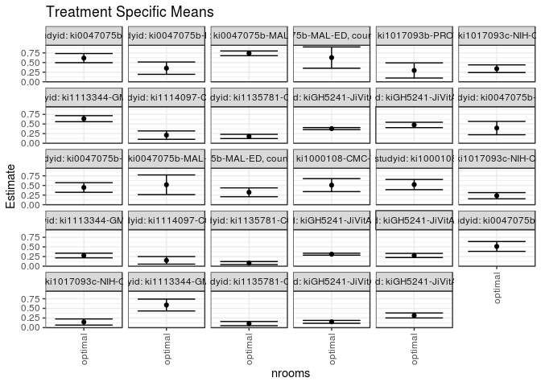

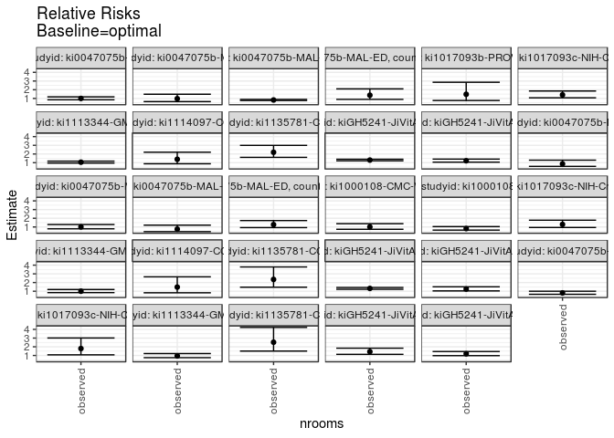

## Results Table

### Parameter: TSM

| agecat | studyid | country | intervention_level | baseline_level | estimate | ci_lower | ci_upper |
| --- | --- | --- | --- | --- | --- | --- | --- |
| 0-24 months | ki0047075b-MAL-ED | INDIA | optimal | NA | 0.6146933 | 0.4960853 | 0.7333013 |
| 0-24 months | ki0047075b-MAL-ED | NEPAL | optimal | NA | 0.3532680 | 0.1931669 | 0.5133690 |
| 0-24 months | ki0047075b-MAL-ED | SOUTH AFRICA | optimal | NA | 0.7391121 | 0.6783906 | 0.7998336 |
| 0-24 months | ki0047075b-MAL-ED | TANZANIA, UNITED REPUBLIC OF | optimal | NA | 0.6281540 | 0.3515103 | 0.9047977 |
| 0-24 months | ki1017093b-PROVIDE | BANGLADESH | optimal | NA | 0.2943203 | 0.0969162 | 0.4917244 |
| 0-24 months | ki1017093c-NIH-Crypto | BANGLADESH | optimal | NA | 0.3391301 | 0.2400099 | 0.4382503 |
| 0-24 months | ki1113344-GMS-Nepal | NEPAL | optimal | NA | 0.6375741 | 0.5593972 | 0.7157509 |
| 0-24 months | ki1114097-CONTENT | PERU | optimal | NA | 0.2105284 | 0.1017663 | 0.3192905 |
| 0-24 months | ki1135781-COHORTS | INDIA | optimal | NA | 0.1765370 | 0.1216484 | 0.2314256 |
| 0-24 months | kiGH5241-JiVitA-3 | BANGLADESH | optimal | NA | 0.3797799 | 0.3532483 | 0.4063114 |
| 0-24 months | kiGH5241-JiVitA-4 | BANGLADESH | optimal | NA | 0.4753741 | 0.4056883 | 0.5450600 |
| 0-6 months | ki0047075b-MAL-ED | INDIA | optimal | NA | 0.3938226 | 0.2206096 | 0.5670356 |
| 0-6 months | ki0047075b-MAL-ED | PERU | optimal | NA | 0.4471378 | 0.3222581 | 0.5720176 |
| 0-6 months | ki0047075b-MAL-ED | SOUTH AFRICA | optimal | NA | 0.5181590 | 0.2623779 | 0.7739401 |
| 0-6 months | ki0047075b-MAL-ED | TANZANIA, UNITED REPUBLIC OF | optimal | NA | 0.3219041 | 0.2069800 | 0.4368282 |
| 0-6 months | ki1000108-CMC-V-BCS-2002 | INDIA | optimal | NA | 0.5082915 | 0.3393197 | 0.6772633 |
| 0-6 months | ki1000108-IRC | INDIA | optimal | NA | 0.5235593 | 0.3913860 | 0.6557327 |
| 0-6 months | ki1017093c-NIH-Crypto | BANGLADESH | optimal | NA | 0.2338898 | 0.1539680 | 0.3138115 |
| 0-6 months | ki1113344-GMS-Nepal | NEPAL | optimal | NA | 0.2767068 | 0.2165215 | 0.3368921 |
| 0-6 months | ki1114097-CONTENT | PERU | optimal | NA | 0.1513559 | 0.0530012 | 0.2497105 |
| 0-6 months | ki1135781-COHORTS | INDIA | optimal | NA | 0.0809431 | 0.0422795 | 0.1196068 |
| 0-6 months | kiGH5241-JiVitA-3 | BANGLADESH | optimal | NA | 0.3109387 | 0.2859243 | 0.3359531 |
| 0-6 months | kiGH5241-JiVitA-4 | BANGLADESH | optimal | NA | 0.2779072 | 0.2239190 | 0.3318954 |
| 6-24 months | ki0047075b-MAL-ED | INDIA | optimal | NA | 0.5127821 | 0.3851731 | 0.6403911 |
| 6-24 months | ki1017093c-NIH-Crypto | BANGLADESH | optimal | NA | 0.1461406 | 0.0669717 | 0.2253095 |
| 6-24 months | ki1113344-GMS-Nepal | NEPAL | optimal | NA | 0.5867607 | 0.4325275 | 0.7409938 |
| 6-24 months | ki1135781-COHORTS | INDIA | optimal | NA | 0.1055412 | 0.0509095 | 0.1601729 |
| 6-24 months | kiGH5241-JiVitA-3 | BANGLADESH | optimal | NA | 0.1506360 | 0.1132826 | 0.1879893 |
| 6-24 months | kiGH5241-JiVitA-4 | BANGLADESH | optimal | NA | 0.3163453 | 0.2514563 | 0.3812343 |

### Parameter: E(Y)

| agecat | studyid | country | intervention_level | baseline_level | estimate | ci_lower | ci_upper |
| --- | --- | --- | --- | --- | --- | --- | --- |
| 0-24 months | ki0047075b-MAL-ED | INDIA | observed | NA | 0.6127660 | 0.5503531 | 0.6751788 |
| 0-24 months | ki0047075b-MAL-ED | NEPAL | observed | NA | 0.3432203 | 0.2825173 | 0.4039234 |
| 0-24 months | ki0047075b-MAL-ED | SOUTH AFRICA | observed | NA | 0.6070039 | 0.5471740 | 0.6668337 |
| 0-24 months | ki0047075b-MAL-ED | TANZANIA, UNITED REPUBLIC OF | observed | NA | 0.8600000 | 0.8169015 | 0.9030985 |
| 0-24 months | ki1017093b-PROVIDE | BANGLADESH | observed | NA | 0.4342857 | 0.3975409 | 0.4710305 |
| 0-24 months | ki1017093c-NIH-Crypto | BANGLADESH | observed | NA | 0.4775726 | 0.4419904 | 0.5131548 |
| 0-24 months | ki1113344-GMS-Nepal | NEPAL | observed | NA | 0.6744186 | 0.6369554 | 0.7118819 |
| 0-24 months | ki1114097-CONTENT | PERU | observed | NA | 0.2930233 | 0.2320422 | 0.3540043 |
| 0-24 months | ki1135781-COHORTS | INDIA | observed | NA | 0.3879792 | 0.3749497 | 0.4010086 |
| 0-24 months | kiGH5241-JiVitA-3 | BANGLADESH | observed | NA | 0.4939352 | 0.4860896 | 0.5017807 |
| 0-24 months | kiGH5241-JiVitA-4 | BANGLADESH | observed | NA | 0.5818282 | 0.5658219 | 0.5978346 |
| 0-6 months | ki0047075b-MAL-ED | INDIA | observed | NA | 0.3404255 | 0.2797123 | 0.4011387 |
| 0-6 months | ki0047075b-MAL-ED | PERU | observed | NA | 0.4485294 | 0.3893160 | 0.5077428 |
| 0-6 months | ki0047075b-MAL-ED | SOUTH AFRICA | observed | NA | 0.3891051 | 0.3293816 | 0.4488285 |
| 0-6 months | ki0047075b-MAL-ED | TANZANIA, UNITED REPUBLIC OF | observed | NA | 0.4080000 | 0.3469565 | 0.4690435 |
| 0-6 months | ki1000108-CMC-V-BCS-2002 | INDIA | observed | NA | 0.5108696 | 0.4597270 | 0.5620121 |
| 0-6 months | ki1000108-IRC | INDIA | observed | NA | 0.4264706 | 0.3784228 | 0.4745184 |
| 0-6 months | ki1017093c-NIH-Crypto | BANGLADESH | observed | NA | 0.3021108 | 0.2694011 | 0.3348205 |
| 0-6 months | ki1113344-GMS-Nepal | NEPAL | observed | NA | 0.2774086 | 0.2416141 | 0.3132032 |
| 0-6 months | ki1114097-CONTENT | PERU | observed | NA | 0.2232558 | 0.1674626 | 0.2790491 |
| 0-6 months | ki1135781-COHORTS | INDIA | observed | NA | 0.1906412 | 0.1799566 | 0.2013259 |
| 0-6 months | kiGH5241-JiVitA-3 | BANGLADESH | observed | NA | 0.4109064 | 0.4034556 | 0.4183572 |
| 0-6 months | kiGH5241-JiVitA-4 | BANGLADESH | observed | NA | 0.3474692 | 0.3322601 | 0.3626783 |
| 6-24 months | ki0047075b-MAL-ED | INDIA | observed | NA | 0.4129032 | 0.3351414 | 0.4906651 |
| 6-24 months | ki1017093c-NIH-Crypto | BANGLADESH | observed | NA | 0.2628458 | 0.2244546 | 0.3012371 |
| 6-24 months | ki1113344-GMS-Nepal | NEPAL | observed | NA | 0.5610329 | 0.5138522 | 0.6082135 |
| 6-24 months | ki1135781-COHORTS | INDIA | observed | NA | 0.2665531 | 0.2530304 | 0.2800757 |
| 6-24 months | kiGH5241-JiVitA-3 | BANGLADESH | observed | NA | 0.2173210 | 0.2079509 | 0.2266911 |
| 6-24 months | kiGH5241-JiVitA-4 | BANGLADESH | observed | NA | 0.3784303 | 0.3598372 | 0.3970234 |

### Parameter: RR

| agecat | studyid | country | intervention_level | baseline_level | estimate | ci_lower | ci_upper |
| --- | --- | --- | --- | --- | --- | --- | --- |
| 0-24 months | ki0047075b-MAL-ED | INDIA | observed | optimal | 0.9968645 | 0.8404344 | 1.1824110 |
| 0-24 months | ki0047075b-MAL-ED | NEPAL | observed | optimal | 0.9715581 | 0.6369333 | 1.4819842 |
| 0-24 months | ki0047075b-MAL-ED | SOUTH AFRICA | observed | optimal | 0.8212609 | 0.7626363 | 0.8843921 |
| 0-24 months | ki0047075b-MAL-ED | TANZANIA, UNITED REPUBLIC OF | observed | optimal | 1.3690910 | 0.8931772 | 2.0985872 |
| 0-24 months | ki1017093b-PROVIDE | BANGLADESH | observed | optimal | 1.4755547 | 0.7612727 | 2.8600287 |
| 0-24 months | ki1017093c-NIH-Crypto | BANGLADESH | observed | optimal | 1.4082281 | 1.0702742 | 1.8528957 |
| 0-24 months | ki1113344-GMS-Nepal | NEPAL | observed | optimal | 1.0577886 | 0.9495877 | 1.1783186 |
| 0-24 months | ki1114097-CONTENT | PERU | observed | optimal | 1.3918469 | 0.8780291 | 2.2063479 |
| 0-24 months | ki1135781-COHORTS | INDIA | observed | optimal | 2.1977216 | 1.6136108 | 2.9932745 |
| 0-24 months | kiGH5241-JiVitA-3 | BANGLADESH | observed | optimal | 1.3005828 | 1.2138006 | 1.3935696 |
| 0-24 months | kiGH5241-JiVitA-4 | BANGLADESH | observed | optimal | 1.2239375 | 1.0627339 | 1.4095936 |
| 0-6 months | ki0047075b-MAL-ED | INDIA | observed | optimal | 0.8644134 | 0.5786485 | 1.2913028 |
| 0-6 months | ki0047075b-MAL-ED | PERU | observed | optimal | 1.0031122 | 0.7867502 | 1.2789752 |
| 0-6 months | ki0047075b-MAL-ED | SOUTH AFRICA | observed | optimal | 0.7509375 | 0.4660766 | 1.2099023 |
| 0-6 months | ki0047075b-MAL-ED | TANZANIA, UNITED REPUBLIC OF | observed | optimal | 1.2674581 | 0.9246433 | 1.7373727 |
| 0-6 months | ki1000108-CMC-V-BCS-2002 | INDIA | observed | optimal | 1.0050720 | 0.7337541 | 1.3767141 |
| 0-6 months | ki1000108-IRC | INDIA | observed | optimal | 0.8145602 | 0.6380413 | 1.0399144 |
| 0-6 months | ki1017093c-NIH-Crypto | BANGLADESH | observed | optimal | 1.2916804 | 0.9375696 | 1.7795353 |
| 0-6 months | ki1113344-GMS-Nepal | NEPAL | observed | optimal | 1.0025364 | 0.8387524 | 1.1983026 |
| 0-6 months | ki1114097-CONTENT | PERU | observed | optimal | 1.4750392 | 0.8191947 | 2.6559505 |
| 0-6 months | ki1135781-COHORTS | INDIA | observed | optimal | 2.3552490 | 1.4646372 | 3.7874212 |
| 0-6 months | kiGH5241-JiVitA-3 | BANGLADESH | observed | optimal | 1.3215030 | 1.2205708 | 1.4307814 |
| 0-6 months | kiGH5241-JiVitA-4 | BANGLADESH | observed | optimal | 1.2503067 | 1.0363707 | 1.5084049 |
| 6-24 months | ki0047075b-MAL-ED | INDIA | observed | optimal | 0.8052216 | 0.6478719 | 1.0007870 |
| 6-24 months | ki1017093c-NIH-Crypto | BANGLADESH | observed | optimal | 1.7985820 | 1.0742361 | 3.0113467 |
| 6-24 months | ki1113344-GMS-Nepal | NEPAL | observed | optimal | 0.9561528 | 0.7483423 | 1.2216712 |
| 6-24 months | ki1135781-COHORTS | INDIA | observed | optimal | 2.5255834 | 1.5089948 | 4.2270337 |
| 6-24 months | kiGH5241-JiVitA-3 | BANGLADESH | observed | optimal | 1.4426903 | 1.1305181 | 1.8410631 |
| 6-24 months | kiGH5241-JiVitA-4 | BANGLADESH | observed | optimal | 1.1962570 | 0.9812360 | 1.4583963 |

### Parameter: PAR

| agecat | studyid | country | intervention_level | baseline_level | estimate | ci_lower | ci_upper |
| --- | --- | --- | --- | --- | --- | --- | --- |
| 0-24 months | ki0047075b-MAL-ED | INDIA | optimal | NA | -0.0019273 | -0.1068403 | 0.1029856 |
| 0-24 months | ki0047075b-MAL-ED | NEPAL | optimal | NA | -0.0100476 | -0.1591710 | 0.1390758 |
| 0-24 months | ki0047075b-MAL-ED | SOUTH AFRICA | optimal | NA | -0.1321082 | -0.1804889 | -0.0837275 |
| 0-24 months | ki0047075b-MAL-ED | TANZANIA, UNITED REPUBLIC OF | optimal | NA | 0.2318460 | -0.0342444 | 0.4979364 |
| 0-24 months | ki1017093b-PROVIDE | BANGLADESH | optimal | NA | 0.1399654 | -0.0546760 | 0.3346068 |
| 0-24 months | ki1017093c-NIH-Crypto | BANGLADESH | optimal | NA | 0.1384424 | 0.0459623 | 0.2309226 |
| 0-24 months | ki1113344-GMS-Nepal | NEPAL | optimal | NA | 0.0368445 | -0.0319332 | 0.1056222 |
| 0-24 months | ki1114097-CONTENT | PERU | optimal | NA | 0.0824949 | -0.0150007 | 0.1799905 |
| 0-24 months | ki1135781-COHORTS | INDIA | optimal | NA | 0.2114422 | 0.1564734 | 0.2664109 |
| 0-24 months | kiGH5241-JiVitA-3 | BANGLADESH | optimal | NA | 0.1141553 | 0.0877510 | 0.1405597 |
| 0-24 months | kiGH5241-JiVitA-4 | BANGLADESH | optimal | NA | 0.1064541 | 0.0395509 | 0.1733573 |
| 0-6 months | ki0047075b-MAL-ED | INDIA | optimal | NA | -0.0533971 | -0.2117834 | 0.1049892 |
| 0-6 months | ki0047075b-MAL-ED | PERU | optimal | NA | 0.0013916 | -0.1072371 | 0.1100202 |
| 0-6 months | ki0047075b-MAL-ED | SOUTH AFRICA | optimal | NA | -0.1290540 | -0.3759959 | 0.1178880 |
| 0-6 months | ki0047075b-MAL-ED | TANZANIA, UNITED REPUBLIC OF | optimal | NA | 0.0860959 | -0.0154700 | 0.1876617 |
| 0-6 months | ki1000108-CMC-V-BCS-2002 | INDIA | optimal | NA | 0.0025780 | -0.1573452 | 0.1625012 |
| 0-6 months | ki1000108-IRC | INDIA | optimal | NA | -0.0970887 | -0.2237147 | 0.0295372 |
| 0-6 months | ki1017093c-NIH-Crypto | BANGLADESH | optimal | NA | 0.0682211 | -0.0068298 | 0.1432719 |
| 0-6 months | ki1113344-GMS-Nepal | NEPAL | optimal | NA | 0.0007018 | -0.0486575 | 0.0500612 |
| 0-6 months | ki1114097-CONTENT | PERU | optimal | NA | 0.0719000 | -0.0180717 | 0.1618716 |
| 0-6 months | ki1135781-COHORTS | INDIA | optimal | NA | 0.1096981 | 0.0706856 | 0.1487106 |
| 0-6 months | kiGH5241-JiVitA-3 | BANGLADESH | optimal | NA | 0.0999677 | 0.0750908 | 0.1248446 |
| 0-6 months | kiGH5241-JiVitA-4 | BANGLADESH | optimal | NA | 0.0695620 | 0.0174323 | 0.1216917 |
| 6-24 months | ki0047075b-MAL-ED | INDIA | optimal | NA | -0.0998789 | -0.2081297 | 0.0083719 |
| 6-24 months | ki1017093c-NIH-Crypto | BANGLADESH | optimal | NA | 0.1167053 | 0.0402038 | 0.1932067 |
| 6-24 months | ki1113344-GMS-Nepal | NEPAL | optimal | NA | -0.0257278 | -0.1696372 | 0.1181817 |
| 6-24 months | ki1135781-COHORTS | INDIA | optimal | NA | 0.1610119 | 0.1060630 | 0.2159608 |
| 6-24 months | kiGH5241-JiVitA-3 | BANGLADESH | optimal | NA | 0.0666851 | 0.0298666 | 0.1035036 |
| 6-24 months | kiGH5241-JiVitA-4 | BANGLADESH | optimal | NA | 0.0620850 | -0.0006070 | 0.1247770 |

### Parameter: PAF

| agecat | studyid | country | intervention_level | baseline_level | estimate | ci_lower | ci_upper |
| --- | --- | --- | --- | --- | --- | --- | --- |
| 0-24 months | ki0047075b-MAL-ED | INDIA | optimal | NA | -0.0031453 | -0.1898608 | 0.1542704 |
| 0-24 months | ki0047075b-MAL-ED | NEPAL | optimal | NA | -0.0292745 | -0.5700230 | 0.3252290 |
| 0-24 months | ki0047075b-MAL-ED | SOUTH AFRICA | optimal | NA | -0.2176398 | -0.3112410 | -0.1307202 |
| 0-24 months | ki0047075b-MAL-ED | TANZANIA, UNITED REPUBLIC OF | optimal | NA | 0.2695884 | -0.1195987 | 0.5234890 |
| 0-24 months | ki1017093b-PROVIDE | BANGLADESH | optimal | NA | 0.3222888 | -0.3135898 | 0.6503532 |
| 0-24 months | ki1017093c-NIH-Crypto | BANGLADESH | optimal | NA | 0.2898878 | 0.0656600 | 0.4603042 |
| 0-24 months | ki1113344-GMS-Nepal | NEPAL | optimal | NA | 0.0546315 | -0.0530886 | 0.1513331 |
| 0-24 months | ki1114097-CONTENT | PERU | optimal | NA | 0.2815302 | -0.1389144 | 0.5467623 |
| 0-24 months | ki1135781-COHORTS | INDIA | optimal | NA | 0.5449833 | 0.3802719 | 0.6659177 |
| 0-24 months | kiGH5241-JiVitA-3 | BANGLADESH | optimal | NA | 0.2311139 | 0.1761415 | 0.2824184 |
| 0-24 months | kiGH5241-JiVitA-4 | BANGLADESH | optimal | NA | 0.1829648 | 0.0590307 | 0.2905756 |
| 0-6 months | ki0047075b-MAL-ED | INDIA | optimal | NA | -0.1568539 | -0.7281647 | 0.2255883 |
| 0-6 months | ki0047075b-MAL-ED | PERU | optimal | NA | 0.0031025 | -0.2710514 | 0.2181240 |
| 0-6 months | ki0047075b-MAL-ED | SOUTH AFRICA | optimal | NA | -0.3316687 | -1.1455698 | 0.1734870 |
| 0-6 months | ki0047075b-MAL-ED | TANZANIA, UNITED REPUBLIC OF | optimal | NA | 0.2110193 | -0.0814981 | 0.4244183 |
| 0-6 months | ki1000108-CMC-V-BCS-2002 | INDIA | optimal | NA | 0.0050464 | -0.3628544 | 0.2736328 |
| 0-6 months | ki1000108-IRC | INDIA | optimal | NA | -0.2276563 | -0.5672966 | 0.0383824 |
| 0-6 months | ki1017093c-NIH-Crypto | BANGLADESH | optimal | NA | 0.2258147 | -0.0665875 | 0.4380555 |
| 0-6 months | ki1113344-GMS-Nepal | NEPAL | optimal | NA | 0.0025299 | -0.1922470 | 0.1654862 |
| 0-6 months | ki1114097-CONTENT | PERU | optimal | NA | 0.3220519 | -0.2207111 | 0.6234870 |
| 0-6 months | ki1135781-COHORTS | INDIA | optimal | NA | 0.5754164 | 0.3172371 | 0.7359681 |
| 0-6 months | kiGH5241-JiVitA-3 | BANGLADESH | optimal | NA | 0.2432858 | 0.1807112 | 0.3010812 |
| 0-6 months | kiGH5241-JiVitA-4 | BANGLADESH | optimal | NA | 0.2001962 | 0.0350943 | 0.3370480 |
| 6-24 months | ki0047075b-MAL-ED | INDIA | optimal | NA | -0.2418942 | -0.5435150 | 0.0007864 |
| 6-24 months | ki1017093c-NIH-Crypto | BANGLADESH | optimal | NA | 0.4440064 | 0.0691059 | 0.6679227 |
| 6-24 months | ki1113344-GMS-Nepal | NEPAL | optimal | NA | -0.0458579 | -0.3362868 | 0.1814491 |
| 6-24 months | ki1135781-COHORTS | INDIA | optimal | NA | 0.6040519 | 0.3373072 | 0.7634275 |
| 6-24 months | kiGH5241-JiVitA-3 | BANGLADESH | optimal | NA | 0.3068505 | 0.1154498 | 0.4568356 |
| 6-24 months | kiGH5241-JiVitA-4 | BANGLADESH | optimal | NA | 0.1640592 | -0.0191229 | 0.3143153 |